# 1. Countplot: criando o nosso primeiro gráfico!

## 1.1. Passos preliminares

### 1.1.1. Nosso primeiro gráfico!

Nesta aula, vamos criar nosso primeiro gráfico usando a função `sns.countplot()`. Trata-se de um gráfico de barras, criado por meio da contagem simples de uma variável categórica. Mas, antes de partirmos para a criação do gráfico propriamente dita, vamos precisar de algumas linhas de código para cumprir etapas preliminares.

### 1.1.2. Importando as bibliotecas necessárias

O primeiro passo consiste em importar as bibliotecas que vamos usar em nosso código. Quando escrevemos um código na linguagem Python podemos utilizar uma série de recursos prontos, ou seja, funções e objetos que já foram criados, para nossa conveniência, por outros programadores.

Alguns desses recursos fazem parte da sintaxe básica da linguagem, ou seja, são recursos que já vem prontos e estão sempre disponíveis quando escrevemos um código na linguagem Python (veja mais informações em: [Built-In Functions](https://docs.python.org/3/library/functions.html)).

Há outros recursos, no entando, que precisamos instalar e carregar para obtermos acesso. Esse é o caso de três bibliotecas amplamente utilizadas para trabalhos de análise de dados em Python: a biblioteca `pandas`, a biblioteca `matplotlib` e a biblioteca `seaborn`.

Vamos começar, antes de mais nada, escrevendo os comandos necessários para importar essas bibliotecas. A importação de bibliotecas é usualmente feita com comandos que seguem a seguinte estrutura:

`import <BIBLIOTECA> as <ALIAS>`

Esse comando não apenas importa a biblioteca mais estabelece um "atalho" ou "apelido" (um *alias*) que será utilizado para se referir ao modulo que foi importado. Isso é útil para simplificar e reduzir o volume de código que vamos precisar escrever, todas vez que quisermos utilizar funções que vêm daquela biblioteca.

Embora possamos utilizar qualquer apelido que escolhermos, existem protocolos muito bem definidos a esse respeito. Isso é importante pois, quando todos os programadores utilizam o mesmo padrão, fica mais fácil ler e entender códigos escritos por outra pessoa.

Sendo assim, leia com atenção o código abaixo. Ele importa as bibliotecas de que precisamos e atribui os atalhos corretos (que já foram consagrados pelo uso e que devemos sempre utilizar como boa prática em nosso código). É uma boa ideia memorizar essas linhas de código, pois iniciamos praticamente todos os códigos de análise de dados com essas exatas linhas:

```python
import pandas as pd
import matplotlib.pyplot as plt
import seaborn as sns
```

Para que o código acima funcione, as bibliotecas `pandas`, `matplotlib` e `seaborn` já devem ter sido instaladas. Neste curso, utilizamos o Python instalado por meio da distribuição Anaconda justamente porque essa instalação acompanha as principais bibliotecas utilizadas em trabalhos de dados, incluindo essas três de que precisamos. Caso você ainda não tenha essas bibliotecas instaladas no seu computador, confira, na documentação oficial do Python, o verbete [Instalando Módulos Python (https://docs.python.org/pt-br/3.7/installing/index.html)](https://docs.python.org/pt-br/3.7/installing/index.html).

Agora vamos ver brevemente para que essas biliotecas servem:

- [**pandas**](https://pandas.pydata.org/docs/): essa biblioteca é utilizada para lidar diretamente com os dados. Ela não apenas permite que a gente leia arquivos no computador (em `.CSV` ou `.XLSX`, por exemplo) e importe para o nosso ambiente de programação como uma tabela de dados (objeto que chamamos no Python de `DataFrame`), mas também contem uma série de funcionalidades para transformar e preparar os dados para as visualizações. Permite agrupamento de variáveis e criação de resumos estatísticos (cálculo de médias, etc.). Por trás dessa biblioteca, há uma outra biblioteca conhecida, chamada `numpy`, que realiza boa parte dessas operações, mas por hora não precisamos nos preocupar com ela.
- [**matplotlib**](https://matplotlib.org/): essa á a biblioteca responsável por gerar os nossos gráficos. A biblioteca `matplotlib` possui muitos recursos e funcionalidades, mas estamos interessados em especial no submódulo `pyplot`, que é o 'motor' por trás da criação dos gráficos. Seria possível criar todos os gráficos deste curso apenas utilizando a biblioteca `matplotlib`. No entanto, a criação de gráficos por ela acaba sendo bastante trabalhosa, pois ela exige que o programador especifique muitos detalhes técnicos do gráfico.
- [**seaborn**](https://seaborn.pydata.org/index.html): essa biblioteca utiliza os recursos disponibilizados pelo módulo `matplotlib.pyplot` para simplificar o processo de criação de gráficos. Ela cuida de boa parte dos detalhes técnicos, oferecendo respostas-padrão razoáveis para os quesitos técnicos da biblioteca `matplotlib.pyplot`, nos desonerando, assim, de realizar todas essas escolhas ao produzir nosso gráfico. Isso é muito útil, pois, com ela, podemos gerar um gráfico com apenas uma linha de código! No entanto, quando se torna importante mudar detalhes técnicos de um gráfico, precisaremos retornar ao módulo `matplotlib.pyplot` para resolver esses problemas.

### 1.1.3. Carregando a base de dados

Agora, tendo importado as bibliotecas necessárias e entendendo para que elas servem, vamos utilizar nossa primeira função para carregar o conjunto de dados que será utilizado em nossa análise. Os dados que vamos carregar mostram informações sobre todos os pagamentos realizados com o cartão presidencial desde o primeiro mandato do presidente Luiz Inácio Lula da Silva, até o mandato do presidente Jair Bolsonaro.

Esses dados foram tratados e podem ser baixados por meio de um link, no formato `CSV`. Para carregá-los utilizaremos o comando a seguir:

```python
cartoes = pd.read_csv("https://bit.ly/dados_cartoes")
cartoes
```

|  | data_pgto | ano | mes | forma_pagamento | valor | tipo_despesa | nome_fornecedor | cpf_servidor | mandato | posicao_mandato |
| --- | --- | --- | --- | --- | --- | --- | --- | --- | --- | --- |
| 0 | 2003-01-02 | 2003 | 1 | Débito | 1696.90 | LOCACAO DE MEIOS DE TRANSPORTE | JW TRANSPORTADORA TURÍSTICA | ***.010.008-** | Lula (1º Mandato) | 1 |
| 1 | 2003-01-02 | 2003 | 1 | Débito | 1336.60 | LOCACAO DE MEIOS DE TRANSPORTE | JW TRANSPORTADORA TURÍSTICA | ***.010.008-** | Lula (1º Mandato) | 1 |
| 2 | 2003-01-02 | 2003 | 1 | Débito | 1396.43 | LOCACAO DE MEIOS DE TRANSPORTE | JW TRANSPORTADORA TURÍSTICA | ***.868.251-** | Lula (1º Mandato) | 1 |
| 3 | 2003-01-03 | 2003 | 1 | Débito | 105.00 | MATERIAL P/MANUTENÇÃO DE BENS MÓVEIS | SEBASTIO ALVES DE SOUSA - ME | ***.262.328-** | Lula (1º Mandato) | 1 |
| 4 | 2003-01-03 | 2003 | 1 | Débito | 200.00 | MATERIAL P/MANUTENÇÃO DE BENS MÓVEIS | JOÃO LEITE NETO - ME - JLN ELETRONICOS | ***.262.328-** | Lula (1º Mandato) | 1 |
| ... | ... | ... | ... | ... | ... | ... | ... | ... | ... | ... |
| 114958 | 2022-12-29 | 2022 | 12 | Crédito | 210.80 | GENEROS DE ALIMENTAÇÃO | ZAIANNA CRISTINA C0MERCIO DE ALIMENTOS LTDA | ***.135.521-** | Jair Bolsonaro | 7 |
| 114959 | 2022-12-29 | 2022 | 12 | Crédito | 536.13 | GENEROS DE ALIMENTAÇÃO | CASA DO CHOCOLATE PRODUTOS ALIMENTICIOS | ***.135.521-** | Jair Bolsonaro | 7 |
| 114960 | 2022-12-29 | 2022 | 12 | Crédito | 673.82 | GENEROS DE ALIMENTAÇÃO | MERCADINHO LA PALMA LTDA | ***.135.521-** | Jair Bolsonaro | 7 |
| 114961 | 2022-12-29 | 2022 | 12 | Crédito | 2147.53 | GENEROS DE ALIMENTAÇÃO | COMPANHIA BRASILEIRA DE DISTRIBUIÇÃO | ***.135.521-** | Jair Bolsonaro | 7 |
| 114962 | 2022-12-31 | 2022 | 12 | Crédito | 36327.36 | SERV.DE APOIO ADMIN.,TECNICO E OPERACIONAL | SIGNATURE FLIGHT SUPPORT | ***.725.557-** | Jair Bolsonaro | 7 |

114963 rows × 10 columns

A primeira linha do código acima executa a função `read_csv()` da biblioteca `pandas` (lembre-se que criamos o atalho `pd` para nos referirmos a esse módulo). Passamos o endereço do arquivo `CSV` que queríamos ler para a função. Com isso, ela lê esse arquivo e salva as informações em uma variável chamada `cartoes`. A função `read_csv()` é capaz de acessar arquivos em nosso computador ou na internet. Caso desejássemos ler um arquivo que está salvo em nosso computador, poderíamos passar o endereço desse arquivo no computador. Neste caso, como queríamos acessar um documento da internet, utilizamos uma url para ler o documento online.

A segunda linha do código, por sua vez, contém apenas o nome da variável que criamos (`cartoes`). Quando a última linha de uma célula de um Notebook como este é o nome de uma variável, o leitor entende que queremos ver o conteúdo da variável. Ou seja, nessa segunda linha, estamos pedindo para ver o conteúdo da variável `cartoes`.

Como podemos observar, a base de dados `cartoes` contém 114.963 linhas que representam, cada uma delas, uma transação distinta realizada com o cartão presidencial no período de referência. Em outras palavras, nossa unidade de observação (ou de análise) neste conjunto de dados é a transação (ou pagamento). Há também 10 colunas, que se referem a 10 variáveis ou características dessas transações. São elas:

- **data_pgto**: a data em que o pagamento foi realizado, no formato YYYY-MM-DD.
- **ano**: O ano em que a transação foi realizada, como número inteiro.
- **mes**: O mês em que a transação foi realizada, como número inteiro (1 = Janeiro, 2 = Fevereiro, etc).
- **forma_pagamento**: A forma de pagamento utilizada, que pode ser `"Crédito"` ou `"Débito"`.
- **valor**: O valor do pagamento realizado, em reais brasileiros (R$), como número decimal.
- **tipo_despesa**: A classificação orçamentária da despesa detalhada.
- **nome_fornecedor**: A razão social ou nome do favorecido.
- **cpf_servidor**: Os 6 últimos dígitos, antes do código verificador, do Cadastro de Pessoa Física (CPF) do agente suprido (que realizou o pagamento).
- **mandato**: Identifica o mandato no qual aconteceu o pagamento.
- **posicao_mandato**: Variável numérica que representa a ordem do mandato no qual aconteceu o pagamento.

## 1.2. Vamos contar categorias!

Agora que já carregamos as bibliotecas e temos uma base de dados para trabalhar, já podemos criar o nosso primeiro gráfico!

### 1.2.1. Argumentos básicos da função `countplot`

Para isso, vamos utilizar a função `countplot()` da biblioteca `seaborn`. Essa função é utilizada quando queremos construir um gráfico de barras simples por meio da contagem de categorias em uma de nossas variáveis.

Sendo assim, vamos começar analisando o número de transações feitas em cada forma de pagamento (`"Crédito"` ou `"Débito"`). Basta indicar o eixo em que queremos representar os nomes das categorias, com o nome da respectiva coluna entre aspas. Vamos colocar as categorias de forma de pagamento no eixo `x`, passando para a função `x="forma_pagamento"`. Por fim, precisamos também especificar a base de dados que estamos utilizando, ou seja, de onde está saindo a coluna `"forma_pagamento"`. Indicamos que queremos usar a base de dados `cartoes` passando para a função `data=cartoes`. Com isso chegamos à linha de código a seguir:

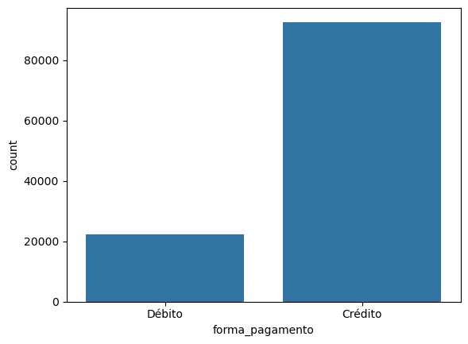

```python
# Criando nosso primeiro gráfico!
sns.countplot(x="forma_pagamento", data=cartoes)
```

Pronto! Com isso já geramos o nosso primeiro gráfico. Percebemos que os pagamentos do cartão presidencial, no período analisado, foram feitos com muito mais frequência em crédito do que em débito.

### 1.2.2. Invertendo os eixos

Agora, como poderíamos mudar um pouco esse gráfico para indicar as categorias de forma de pagamento no eixo y e a contagem do número de transações no eixo x (invertendo o gráfico acima)? Ora, bastaria vincular a nossa variável categórica ao eixo y, passando `y="forma_pagamento"` para a função `countplot()`, como se vê a seguir:

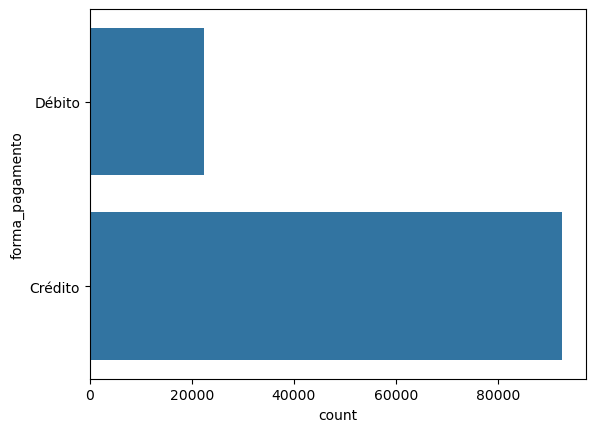

```python
sns.countplot(y="forma_pagamento", data=cartoes)
```

Simples, não? Já conseguimos criar nosso primeiro gráfico de contagem de frequência e ainda temos uma forma simples de escolher em qual eixo queremos representar nossa contagem. Mas talvez você esteja por que seria útil escolher o eixo como fizemos agora.

Para reponder a essa pergunta, vamos criar um novo gráfico, dessa vez utilizando outra variável categórica presente nos nossos dados: o `mandato` presidencial de cada transação. No código a seguir, começamos novamente indicando os mandatos no eixo x:

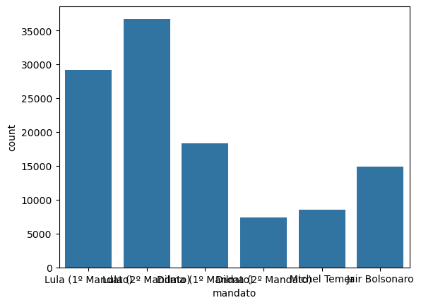

```python
sns.countplot(x="mandato", data=cartoes)
```

O que você acha desse gráfico? Conseguimos ler bem o nome dos mandatos no eixo x? Não, definitivamente não está legível. Os nomes das categorias estão sobrepostos e torna-se muito difícil distinguir as categorias representadas no gráfico.

Isso acontece porque a nossa linguagem se escreve da esquerda para a direita, ou seja, no mesmo sentido do eixo x de um gráfico. Por conta disso, sempre que temos um grande número de categorias, ou nomes extensos das categorias, é comum que surjam problemas de sobreposição dos nomes das categorias. Uma forma bem simples de lidar com isso (existem outras que veremos mais à frente) é mudar o eixo em que essas categorias estão representadas. Veja como fica o nosso gráfico dos mandatos quando invertemos os eixos:

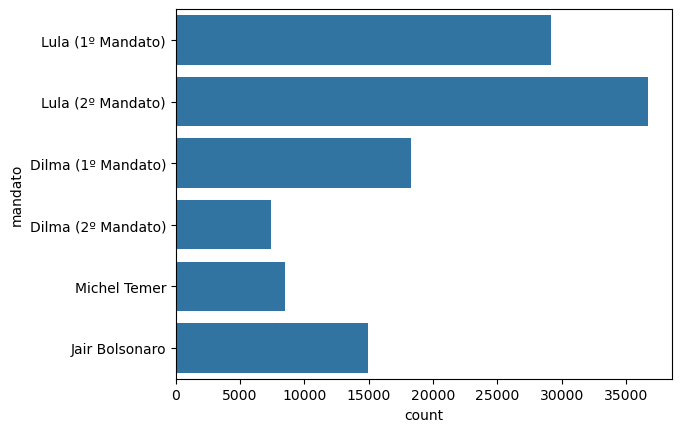

```python
sns.countplot(y="mandato", data=cartoes)
```

Agora podemos ver com facilidade os nomes dos mandatos e a contagem dos pagamentos. Sabendo disso, de acordo com o nosso gráfico:

**Qual presidente gastou mais durante o seu mandato?**

Você pensou imediatamente que o presidente que gastou mais foi o Lula em seu segundo mandato? **Tome cuidado!** O nosso gráfico não permite tirar essa conclusão. Não sabemos o valor das transações, apenas o número total de transações. O gráfico está dizendo, apenas, que o maior número de transações foi realizado durante o segundo mandato do presidente Lula. No entanto, se o valor médio dessas transações for inferior ao de outros mandatos, é possível que o gasto total nesse mandato não tenha sido o mais alto (veremos no próximo capítulo que, de fato, não é!).

Esta pergunta está aqui como aviso de algo que será fundamental para você sempre que estiver analisando dados: tenha clareza do que está sendo medido e como. Se atente para a unidade de análise utilizada e sempre busque saber exatamente como cada dimensão do gráfico está sendo representada.

### 1.2.3. A função `countplot` nunca aprendeu a somar :(

Nós temos uma variável em nossa base de dados que indica o valor de cada transação. E aí, será que conseguimos utilizá-la com a função `countplot` para calcular o gasto total de cada mandato presidencial?

Infelizmente, a resposta nesse caso é não. A função `countplot` não sabe agregar uma variável numérica para cruzá-la com uma variável categórica. Se tentamos passar uma variável numérica para o eixo x do nosso gráfico, junto com nossa variável categórica no eixo y, obteremos uma mensagem de erro dizendo que só podemos usar um único eixo com a função `countplot`. Veja a última linha da mensagem de erro gerada pelo código a seguir:

```python
sns.countplot(y="mandato", x="valor", data=cartoes)
```

```
---------------------------------------------------------------------------
TypeError                                 Traceback (most recent call last)
Cell In[7], line 1
----> 1 sns.countplot(y="mandato", x="valor", data=cartoes)

File /opt/anaconda3/lib/python3.12/site-packages/seaborn/categorical.py:2629, in countplot(data, x, y, hue, order, hue_order, orient, color, palette, saturation, fill, hue_norm, stat, width, dodge, gap, log_scale, native_scale, formatter, legend, ax, **kwargs)
   2627     y = 1 if list(x) else None
   2628 elif x is not None and y is not None:
-> 2629     raise TypeError("Cannot pass values for both `x` and `y`.")
   2631 p = _CategoricalAggPlotter(
   2632     data=data,
   2633     variables=dict(x=x, y=y, hue=hue),
   (...)
   2637     legend=legend,
   2638 )
   2640 if ax is None:

TypeError: Cannot pass values for both `x` and `y`.
```

Mas, não se preocupe! O `seaborn` possui uma função que sabe tirar médias, somar ou fazer ainda inúmeras outras operações de agregação de uma variável numérica para relacioná-la a uma variável categórica. Trata-se da função `barplot`, que conheceremos no próximo capítulo desta apostila. Aguarde!

### 1.2.4. Usando cores para cruzar categorias

Vamos encerrar este primeiro capítulo aprendendo a cruzar duas variáveis categóricas, que serão representadas como barras de cores diferentes em nosso gráfico. Para isso, basta utilizar o argumento `hue`, que associada cada categoria a uma cor e cria uma legenda em nosso gráfico para indicar as cores. Precisamos definir de qual coluna dos nossos dados vamos extrair as categorias que serão representadas como cores distintas no gráfico.

Observe o código a seguir. Nele estamos criando um gráfico de contagem de transações por mandato, colocando as categorias de mandato no eixo y (`y="mandato"`). Além disso, estamos contando separadamente, em cada mandato, o número de transações realizadas em cada forma de pagamento, crédito ou débito (`hue="forma_pagamento"`).

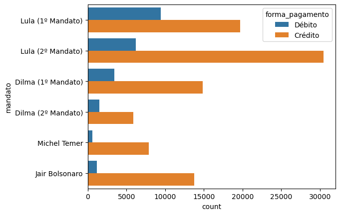

```python
sns.countplot(
    y="mandato",
    hue="forma_pagamento",
    data=cartoes
)
```

O gráfico nos permite observar que houve uma clara tendência de redução do número de transações realizadas em débito ao longo dos mandatos presidenciais. Essa tendência, inclusive, parece se confirmar mesmo quando o número total de transações cresce de um mandato para o outro. O gráfico que criamos já é capaz de evidenciar, portanto, uma relação complexa entre as informações disponíveis acerca dos pagamentos, algo que dificilmente conseguiríamos identificar facilmente apenas trabalhando diretamente os dados tabulares, sem tentar produzir visualizações.

## 1.3. Ainda há muito mais...

Se você conseguiu acompanhar esta apostila até aqui, parabéns! Você aprendeu a carregar as principais bibliotecas utilizadas na ciência de dados e a usar uma url para carregar uma base de dados. Você já sabe como criar um gráfico de frequência de uma variável categórica de uma base de dados, já sabe quando utilizar barras verticais (eixo x) ou horizontais (eixo y) de forma a acomodar melhor os nomes das variáveis no gráfico. Por fim, você aprendeu também a utilizar cores para cruzar duas variáveis categóricas, produzindo uma representação complexa e potencialmente informativa dos dados analisados!

Esses aprendizados já formam um excelente primeiro contato com o mundo da análise e visualização de dados. No entanto, é claro que ainda há muito o que aprender. Para mostrar um pouco das customizações que aprenderemos a fazer ao longo do curso, deixamos a seguir um exemplo de um código mais "bem acabado" para produzir o último gráfico que havíamos mostrado, que conta o número de transações por forma de pagamento, por mandato.

Não se preocupe em entender tudo o que acontece nesse código. Veremos com mais calma, ao longo do curso, como funcionam essas customizações.

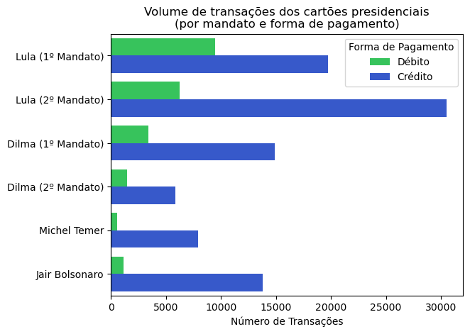

```python
fig, ax = plt.subplots()

# Contagem de transações por forma de pagamento e por mandato
sns.countplot(
    y="mandato",
    hue="forma_pagamento",
    palette={"Crédito": "#1e4ce3", # indicação da palheta de cores
             "Débito": "#1fdb51"},
    data=cartoes,
    ax=ax
)

# Adicionar título ao gráfico
ax.set_title("Volume de transações dos cartões presidenciais\n(por mandato e forma de pagamento)")

# Especificar o nome do eixo x
ax.set_xlabel("Número de Transações")

# Remover o nome do eixo y
ax.set_ylabel("")

# Especificar o título da legenda
ax.legend(title="Forma de Pagamento")

plt.show()
```